# Predicting Incorrect Barbell Movements from Wearables

Triston Cossette

5/25/2017

## Executive Summary

People often times do exercises incorrectly, and it is difficult for them to spot how. This analysis looks at answering one question:

1. Can we use wearable technology to assess if an exercise has been done correctly?

The approach is to manually observe a large number of exercises and tag them as being correct or incorrect (in a variety of ways). We then will apply model-building techniques to see if we can accurately predict if an exercise has been done correctly.

## Getting and Cleaning the data

First, we’ll download the data and store it an r object. I’ll load up some important packages as well, and set the seed right away.

```r
 if (!file.exists("Activity.csv"))
    {
      download.file("https://d396qusza40orc.cloudfront.net/predmachlearn/pml-training.csv", destfile="Activity.csv", cacheOK=T)
 }

act<-read.csv("Activity.csv",header=TRUE)

##Get Packages
library(caret)
set.seed(5252017)

##Check Dims/Features
dim(act)
```

```
## [1] 19622   160
```

Next, we’ll need to remove all columns with the following prefixes. They appear to be summary fields only present on summary rows. By removing these fields, we’ll have a nice fully-fililed dataframe ready for modeling.

```r
#Clean up some weird datafields
act<-act[,-grep("amplitude_",colnames(act))]
act<-act[,-grep("avg_",colnames(act))]
act<-act[,-grep("min_",colnames(act))]
act<-act[,-grep("max_",colnames(act))]
act<-act[,-grep("stddev_",colnames(act))]
act<-act[,-grep("kurtosis_",colnames(act))]
act<-act[,-grep("skewness_",colnames(act))]
act<-act[,-grep("var_",colnames(act))]

##Remove identity and time-based variables
act<-act[,-(1:7)]
```

## Split into Training and Test Sets.

Now, we’ll split our data into appropriate datasets. I chose to use a 25% test and 75% training…arbitrarily. Since we have a lot of data, there’s not too much point in repeated testing of models. Theoretically we should have low variablity, and we shouldn’t overfit and bias our model too much with the data that we have. So let’s just keep it simple and see how it goes.

```r
Intrain<-createDataPartition(as.vector(act$classe), p=0.75, list=FALSE)
Training<-act[Intrain,]
Testing<-act[-Intrain,]
```

## PCA Preprocessing

This data set contains a lot of features, and honestly, my computer is having trouble running complex models on them. Probably not idea. So to trim the data I’m using, I’m going to do a quick PCA:

```r
preProcess(Training[,-53],method='pca')
```

```
## Created from 14718 samples and 52 variables
##
## Pre-processing:
##   - centered (52)
##   - ignored (0)
##   - principal component signal extraction (52)
##   - scaled (52)
##
## PCA needed 25 components to capture 95 percent of the variance
```

Which appears to trim the number of variables by almost half, which is really good for compression. Let’s go ahead and use PCA, but bake it in to our models witn Train in Caret.

## Fit Model 1, GBM, and Check Accuracy

Since we are using numeric variables to predict categorical variables, we have a good sense of what kind of models to use. I have first selected a General Boosted Model, as I suspect that we may have a lot of variables that contribute marginally to the whole prediction. Let’s see if I’m right:

```r
Fit1<-train(classe ~ ., method="gbm",preProcess="pca",data=Training)
```

```r
Pred1<-predict(Fit1, Testing)
table(Pred1,Testing$classe)
```

```
##
## Pred1    A    B    C    D    E
##     A 1256  110   37   41   22
##     B   27  705   56   25   84
##     C   45   85  713   82   64
##     D   56   16   33  644   43
##     E   11   33   16   12  688
```

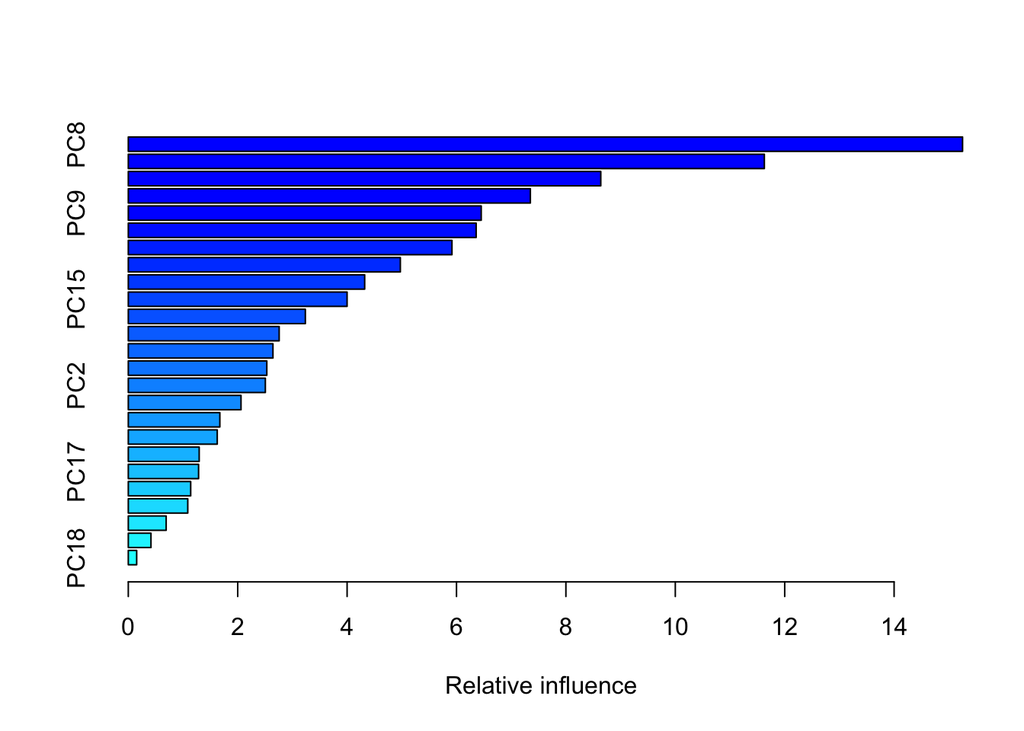

```
##       var    rel.inf
## PC8   PC8 15.2515247
## PC14 PC14 11.6279731
## PC5   PC5  8.6377833
## PC12 PC12  7.3502862
## PC9   PC9  6.4520836
## PC3   PC3  6.3595820
## PC1   PC1  5.9173056
## PC25 PC25  4.9734737
## PC21 PC21  4.3215293
## PC15 PC15  3.9999934
## PC16 PC16  3.2367983
## PC22 PC22  2.7582849
## PC7   PC7  2.6447130
## PC13 PC13  2.5324797
## PC2   PC2  2.5055931
## PC10 PC10  2.0608094
## PC6   PC6  1.6738546
## PC20 PC20  1.6261521
## PC23 PC23  1.2961733
## PC17 PC17  1.2848975
## PC19 PC19  1.1408948
## PC4   PC4  1.0874709
## PC24 PC24  0.6924332
## PC11 PC11  0.4146088
## PC18 PC18  0.1533015
```

```r
summary(Fit1)
```

It looks like our misclassification rate here is only 0.183

It also looks like a GBM is a good model to use here because it looks like a lot of the variables add to explaining the variance. Let’s try one more model before we are sold, though.

## Fit Model 2, Random Forest, and check accuracy

A Random Forest Model is another model type that is appropriate for predicting a categorical variable from a matrix.

```r
Fit2<-train(classe ~ ., method="rf", preProcess="pca", data=Training)
```

[output not shown]

[output cut: 91 more lines]

[output not shown]

```r
Pred2<-predict(Fit2, Testing)
table(Pred2,Testing$classe)
```

```
##
## Pred2    A    B    C    D    E
##     A 1382   16    0    0    0
##     B    3  921    6    0    0
##     C    7   10  835   22   10
##     D    1    0   12  781    7
##     E    2    2    2    1  884
```

## Final Model

Our expected misclassification Rate is just over our Random Forest misclassificaiton rate, 0.021

## Conclusion

Our conclusion is that indeed, using simple model building techniques we can predict if and how an exercise has been done correctly with 0.979 . In this case to be specific, our accuracy is 1-misclassification rate.